# Narrative Visualization Project

CS 498, Data Visualization, Summer 2020

Ramin Melikov

University of Illinois at Urbana-Champaign  
melikov2@illinois.edu

August 01, 2020

# Visualizing Turnover

In this article, I am going to show how to powerfully visualize a turnover problem. The problem of turnover comes in many forms like employee turnover, order fulfilment, defect remedy, agile project story points, etc. In essence, it is this: number of outstanding issues vs number of issues resolved with respect to a period `t`. I will be using a dataset that I adopted from one of my previous consulting engagements where I was analyzing software defects.

Software defects, especially the ones that are labeled as critical, need to be resolved as soon as possible and managers need to be able to see how their teams are doing with respect to reducing the number of outstanding issues. Just by looking at how many outstanding issues there are doesn’t tell managers about how their team is doing. There needs to be a visualization that shows a pattern and gives an idea to the manager about the action he or she needs to take.

Here is an example (a screenshot from Tableau) of what that visualization would look like. Below we see an image that shows two charts over the same time period. We see blue, red, and orange lines, with orange on its own and representing the turnover, and blue and red representing outstanding defects and resolved defects respectively.

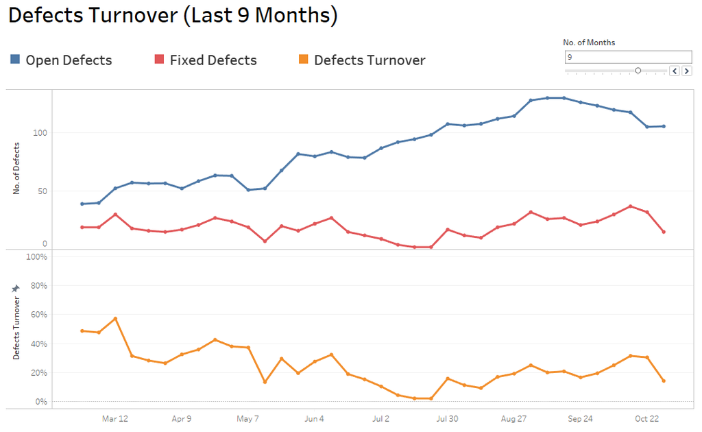

The image above tells us that the team that is working on resolving the defects is losing control of the situation and suggests that the intervention is needed. We see that the turnover (orange) line is going down toward 0% and the gap between outstanding (blue) and resolved (red) lines is widening, which is bad in this case.

**Note: It is important to understand that this is not opened vs. closed items; this is open vs closed items.**

So, the question is then *how do we visualize it, what data would we need, and in what shape would the data have to be?*

The data must have the following constraints:

- Each row must be a unique observation
- Each row must have a “start date”
- Some rows’ “end dates” will be null
- If exists, “end date” >= “start date”

For example, all defects will have a start date (the date defect was discovered) and some will have an end date (the date defect was resolved).

**The next important step would be is to transform the dataset so that each defect row is replicated the number of times that is equal to the number of days (or periods `t`) it took to resolve the issue. If the issue is still open, then the that number should be the equal to `"current date" - "start date" + 1`. Also, the dataset needs a `Date` column, which contains all of the dates that the defect is open.**

I already have the dataset transformed into the right shape. The “current date” of the dataset is `2017-10-31`. We’ll be looking at it as if we are looking at it on `2017-10-31`.

Let’s get the data.

```r
defects <- read.csv('software_defects.csv')
defects$DATE <- as.Date(defects$DATE, format = "%m/%d/%Y")
defects$CLOSING_DATE <- as.Date(defects$CLOSING_DATE, format = "%m/%d/%Y")
defects$DETECTION_DATE <- as.Date(defects$DETECTION_DATE, format = "%m/%d/%Y")
#str(defects)
```

**Below we can see that the defect with ID `1316`, which took 8 days to close, has `8` records in the dataset.**

```r
subset(defects, BUG_ID == 1316)[,1:6]
```

```
##       BUG_ID STATUS SEVERITY DETECTION_DATE ACTUAL_FIX_TIME CLOSING_DATE
## 11836   1316 Closed 2-Medium     2017-01-02               8   2017-01-09
## 11837   1316 Closed 2-Medium     2017-01-02               8   2017-01-09
## 11838   1316 Closed 2-Medium     2017-01-02               8   2017-01-09
## 11839   1316 Closed 2-Medium     2017-01-02               8   2017-01-09
## 11840   1316 Closed 2-Medium     2017-01-02               8   2017-01-09
## 11841   1316 Closed 2-Medium     2017-01-02               8   2017-01-09
## 11842   1316 Closed 2-Medium     2017-01-02               8   2017-01-09
## 11843   1316 Closed 2-Medium     2017-01-02               8   2017-01-09
```

**We can also see that the defect with ID `2206`, which is still open as of `2017-10-31`, has `9` records in the dataset because `31 - 23 + 1 = 9`.**

```r
subset(defects, BUG_ID == 2206)[,1:6]
```

```
##       BUG_ID STATUS SEVERITY DETECTION_DATE ACTUAL_FIX_TIME CLOSING_DATE
## 11957   2206   Fail 2-Medium     2017-10-23              NA         <NA>
## 11958   2206   Fail 2-Medium     2017-10-23              NA         <NA>
## 11959   2206   Fail 2-Medium     2017-10-23              NA         <NA>
## 11960   2206   Fail 2-Medium     2017-10-23              NA         <NA>
## 11961   2206   Fail 2-Medium     2017-10-23              NA         <NA>
## 11962   2206   Fail 2-Medium     2017-10-23              NA         <NA>
## 11963   2206   Fail 2-Medium     2017-10-23              NA         <NA>
## 11964   2206   Fail 2-Medium     2017-10-23              NA         <NA>
## 11965   2206   Fail 2-Medium     2017-10-23              NA         <NA>
```

**Here is the structure of our data. Note that the `NOR` column is for `Number of Records`, with each cell having a value of `1`. It is a helper column. It helps when counting rows.**

```r
str(defects)
```

```
## 'data.frame':    22540 obs. of  8 variables:
##  $ BUG_ID         : int  2237 2239 2163 2163 2163 2163 2163 2163 2163 2163 ...
##  $ STATUS         : Factor w/ 5 levels "Assigned","Closed",..: 2 2 2 2 2 2 2 2 2 2 ...
##  $ SEVERITY       : Factor w/ 4 levels "1-Low","2-Medium",..: 4 3 3 3 3 3 3 3 3 3 ...
##  $ DETECTION_DATE : Date, format: "2017-10-31" "2017-10-31" ...
##  $ ACTUAL_FIX_TIME: int  1 1 20 20 20 20 20 20 20 20 ...
##  $ CLOSING_DATE   : Date, format: "2017-10-31" "2017-10-31" ...
##  $ DATE           : Date, format: "2017-10-31" "2017-10-31" ...
##  $ NOR            : int  1 1 1 1 1 1 1 1 1 1 ...
```

**Here are our time series aggregate data.**

```r
reported_defects <- aggregate(NOR ~ DATE, defects, sum)
names(reported_defects)[names(reported_defects)=="NOR"] <- "OPEN_DEFECTS"
reported_defects <- reported_defects[order(reported_defects$DATE),]

fixed_defects <- aggregate(
      CLOSED_DEFECTS ~ DATE
    , data = within(defects, CLOSED_DEFECTS <- ifelse(CLOSING_DATE == DATE, BUG_ID, NA))
    , function (x) if(length(x) > 0) length(unique(x)) - 1 else 0
    , na.action = na.pass
)
fixed_defects <- fixed_defects[order(fixed_defects$DATE),]

defects <- merge(reported_defects, fixed_defects, by = 'DATE')

defects <- within(defects, TURNOVER <- CLOSED_DEFECTS/OPEN_DEFECTS)
```

Now that we have our data we want to first create a time series chart.

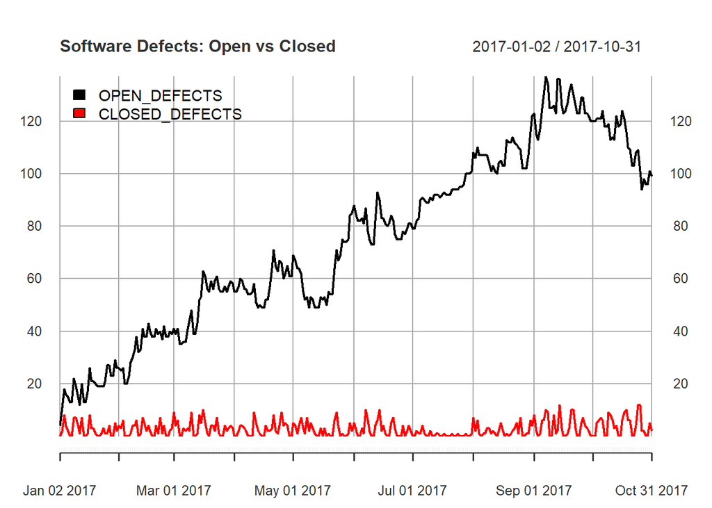

```r
library(xts)
data_ts <- xts(defects[, -1], order.by = defects[, 1])
plot(data_ts[,1:2], legend.loc = "topleft", main = "Software Defects: Open vs Closed")
```

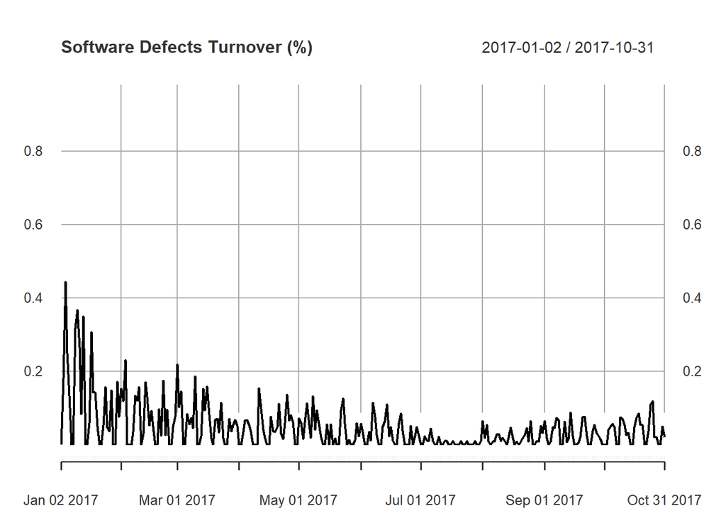

```r
plot(data_ts[,3], main = "Software Defects Turnover (%)", ylim = c(0, 1))
```